# SNAProjectNetflixPrize

Davide Guidobene

9/1/2021

```r
rm(list = ls())
set.seed(76418)
```

#libraries

```r
library(lubridate)
library(dplyr)
library(zoo)
```

```r
library(recosystem)
library(Matrix)
library(ggplot2)
library(igraph)
```

#Utility functions

```r
plot_deg_distr <- function(g, node_type){
  G.degrees <- degree(g, V(g)[V(g)$type==node_type])
  G.degree.histogram <- as.data.frame(table(G.degrees))
  G.degree.histogram[,1] <- as.numeric(G.degree.histogram[,1])
  if(node_type)
    type_name = "Users"
  else
    type_name = "Movies"
  ggplot(G.degree.histogram, aes(x = G.degrees, y = Freq)) +
      geom_point() +
      scale_x_continuous("Degree\n(nodes with this amount of connections)",
                         breaks = c(1, 3, 10, 30, 100, 300),
                         trans = "log10") +
      scale_y_continuous("Frequency\n(how many of them)",
                         breaks = c(1, 3, 10, 30, 100, 300, 1000),
                         trans = "log10") +
      ggtitle(paste(type_name, "Degree Distribution (log-log)")) +
      theme_bw()
}

get_users <- function(g) {
  return (V(g)[V(g)$type==T])
}

get_movies <- function(g) {
  return (V(g)[V(g)$type==F])
}
```

#DATA PREPARATION – TRAINING DATA

```r
path <- "C:/Users/david/OneDrive/Desktop/New"
setwd(path)
nf <- read.table("Data/combined_data.txt",sep=",",header=FALSE,fill=TRUE)
head(nf)
```

```
##        V1 V2         V3
## 1      1: NA
## 2 1488844  3 2005-09-06
## 3  822109  5 2005-05-13
## 4  885013  4 2005-10-19
## 5   30878  4 2005-12-26
## 6  823519  3 2004-05-03
```

```r
# this is how the data looks like - In this preview, "1:" is the movie ID, and the rows that come after ("1488844", "822109", etc) are the user ID.
# generally, the indicator of rows which contain the movie ID lies in the presence of ":".
# V2 is the rating data
# V3 is the date on which the rating was given for a certain movie ID
```

#In order to be interpretable, the above format has to be transformed into the data frame which contains these columns: Movie ID, User ID, Rating, and Date

```r
nf$V4 <- nf$V1 #creating 2 separate columns, V1 will be dedicated for Movie ID, while V4 will be dedicated for User ID
nf$V1[!grepl(":",nf$V1)] <- NA #if the V1 column does NOT contain ":", it will be changed into NA
nf$V1 <- gsub(":","",nf$V1) #replacing the ":" with "" -- this function is basically aimed at removing the ":" character in the movie ID
nf$V1 <- na.locf(nf$V1) #Replaces each missing value (the NAs) with the most recent present value prior to it (Last Observation Carried Forward) -- that is, the most recent "Movie ID" prior to it
nf <- filter(nf,!grepl(":",nf$V4)) #removing the rows containing ":" in the V4 column from the observation
nf <- nf[,c("V1","V4","V2","V3")] #restructuring the order of the columns
names(nf) <- c("movie_id", "user_id","rating","date")

head(nf)
```

```
##   movie_id user_id rating       date
## 1        1 1488844      3 2005-09-06
## 2        1  822109      5 2005-05-13
## 3        1  885013      4 2005-10-19
## 4        1   30878      4 2005-12-26
## 5        1  823519      3 2004-05-03
## 6        1  893988      3 2005-11-17
```

```r
str(nf) #checking the data type of each column
```

```
## 'data.frame':    24053764 obs. of  4 variables:
##  $ movie_id: chr  "1" "1" "1" "1" ...
##  $ user_id : chr  "1488844" "822109" "885013" "30878" ...
##  $ rating  : int  3 5 4 4 3 3 4 3 4 3 ...
##  $ date    : chr  "2005-09-06" "2005-05-13" "2005-10-19" "2005-12-26" ...
```

```r
nf$movie_id <- as.numeric(nf$movie_id)
nf$user_id <- as.numeric(nf$user_id)

nf$rating <- as.numeric(nf$rating)
nf$date <- as.Date(nf$date, "%Y-%m-%d")
summary(nf)
```

```
##     movie_id       user_id            rating         date
##  Min.   :   1   Min.   :      6   Min.   :1.0   Min.   :1999-11-11
##  1st Qu.:1180   1st Qu.: 660927   1st Qu.:3.0   1st Qu.:2004-04-30
##  Median :2342   Median :1318602   Median :4.0   Median :2005-01-19
##  Mean   :2308   Mean   :1322285   Mean   :3.6   Mean   :2004-10-10
##  3rd Qu.:3433   3rd Qu.:1984358   3rd Qu.:4.0   3rd Qu.:2005-06-30
##  Max.   :4499   Max.   :2649429   Max.   :5.0   Max.   :2005-12-31
```

```r
head(nf)
```

```
##   movie_id user_id rating       date
## 1        1 1488844      3 2005-09-06
## 2        1  822109      5 2005-05-13
## 3        1  885013      4 2005-10-19
## 4        1   30878      4 2005-12-26
## 5        1  823519      3 2004-05-03
## 6        1  893988      3 2005-11-17
```

#Netflix rating method changed in 2004

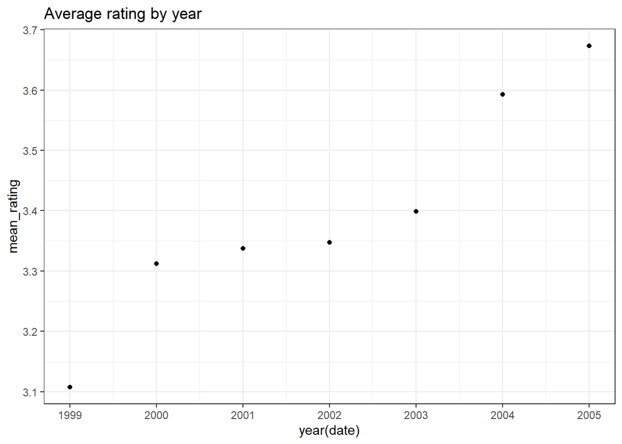

```r
mean_rating = nf %>%
  group_by(year(date)) %>%
  summarize(mean_rating = mean(rating))
ggplot(mean_rating, aes(`year(date)`, mean_rating)) +
      geom_point() +
      scale_x_continuous(breaks = mean_rating$`year(date)`) +
      scale_y_continuous(breaks = seq(from=3, to=4, by=0.1)) +
      ggtitle("Average rating by year") +
      theme_bw()
```

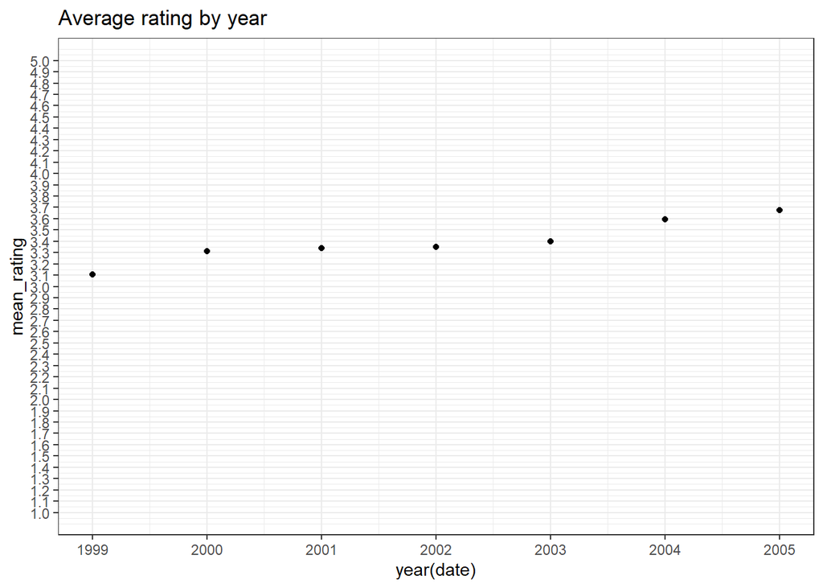

```r
ggplot(mean_rating, aes(`year(date)`, mean_rating)) +
      geom_point() +
      scale_x_continuous(breaks = mean_rating$`year(date)`) +
      scale_y_continuous(breaks = seq(from=1, to=5, by=0.1), limits = c(1, 5)) +
      ggtitle("Average rating by year") +
      theme_bw()
```

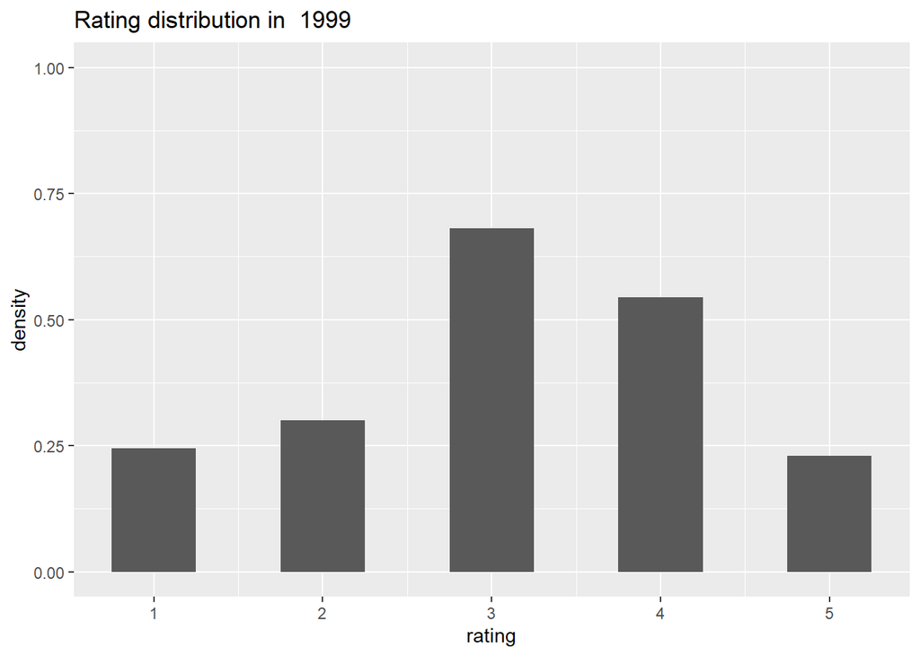

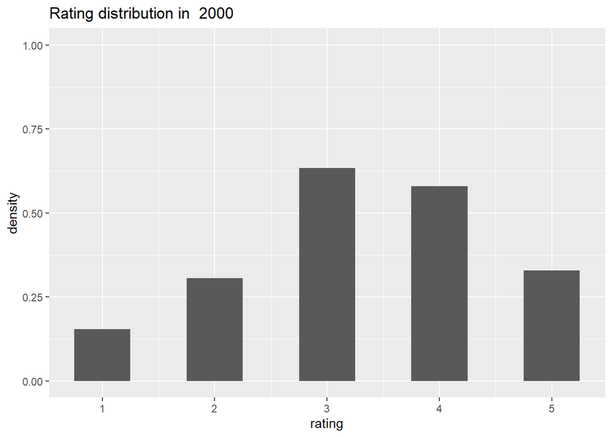

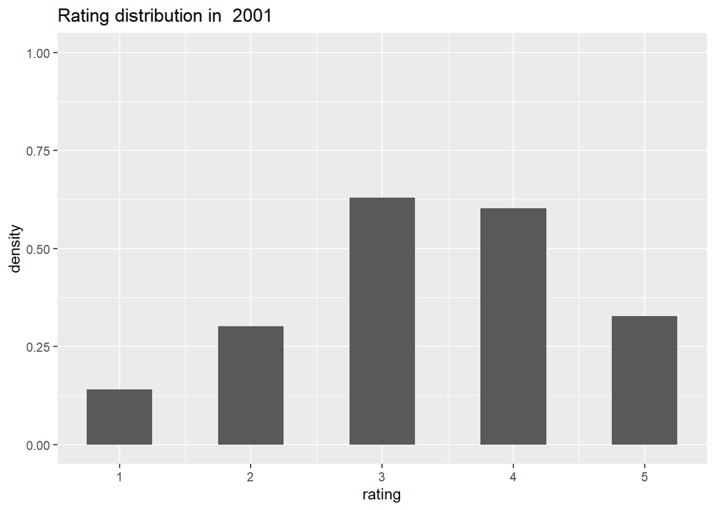

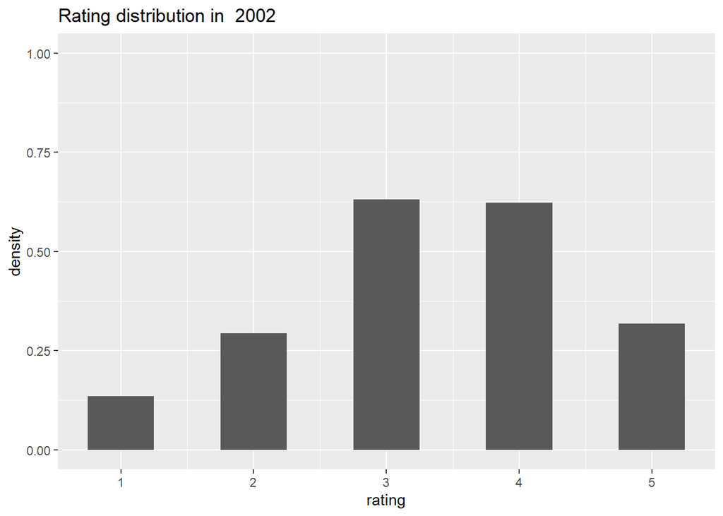

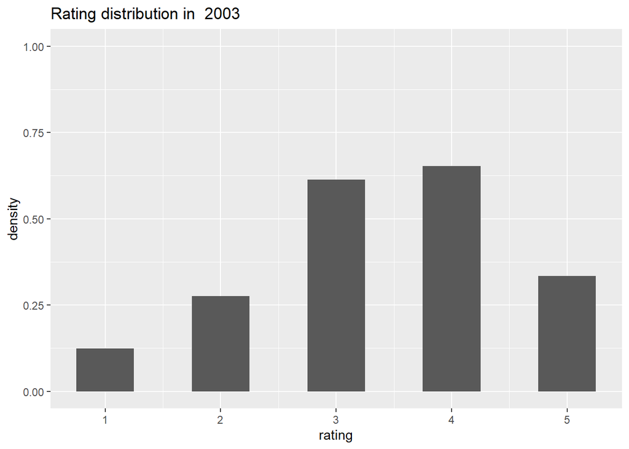

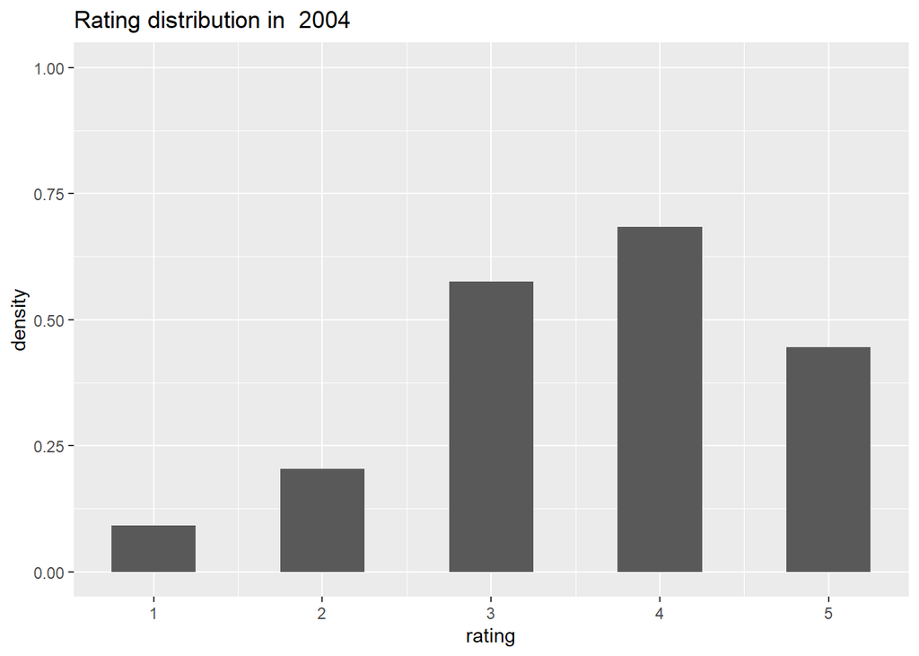

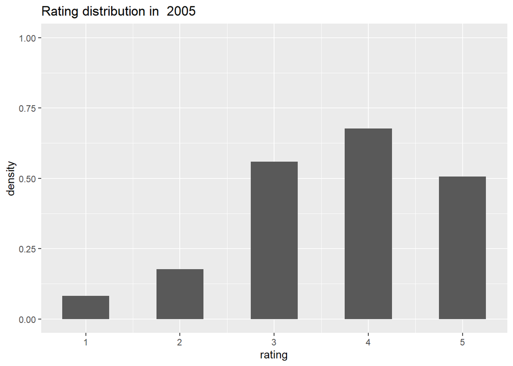

```r
for (yr in min(year(nf$date)) : max(year(nf$date))) {
  print(ggplot(nf[year(nf$date) == yr,], aes(x = rating)) +
    geom_histogram(aes(y =..density..),
                   bins = 9) +
      scale_y_continuous(limits = c(0, 1)) +
    ggtitle(paste("Rating distribution in ", yr))
  )
}
```

```r
#Since in 2004 Netflix changed the text accompanying the star ratings changed from an objective scale (excellent, good, fair, …) to a subjective scale (loved it, liked it, …), the average rating of the audience showed a significant improvement.
```

```r
#For this reason I decided to either keep all the reviews either before or after that year.
sum(year(nf$date)<2004)
```

```
## [1] 3921909
```

```r
sum(year(nf$date)>2004)
```

```
## [1] 12562227
```

```r
#Since the reviews after 2004 are significantly more and the only relevant ones to predict future data, I decided to keep those
nf <- nf[year(nf$date)>2004,]
head(nf)
```

```
##    movie_id user_id rating       date
## 1         1 1488844      3 2005-09-06
## 2         1  822109      5 2005-05-13
## 3         1  885013      4 2005-10-19
## 4         1   30878      4 2005-12-26
## 6         1  893988      3 2005-11-17
## 10        1 2238063      3 2005-05-11
```

```r
summary(nf)
```

```
##     movie_id       user_id            rating           date
##  Min.   :   1   Min.   :      6   Min.   :1.000   Min.   :2005-01-01
##  1st Qu.:1180   1st Qu.: 663990   1st Qu.:3.000   1st Qu.:2005-03-28
##  Median :2360   Median :1324036   Median :4.000   Median :2005-06-24
##  Mean   :2310   Mean   :1324817   Mean   :3.673   Mean   :2005-06-22
##  3rd Qu.:3427   3rd Qu.:1987044   3rd Qu.:5.000   3rd Qu.:2005-09-15
##  Max.   :4499   Max.   :2649429   Max.   :5.000   Max.   :2005-12-31
```

#Let’s make sure movie_id and user_id don’t have any common label

```r
#nf$movie_id <- match(nf$movie_id, unique(nf$movie_id))
user_id_offset <- max(nf$movie_id)
nf$user_id <- user_id_offset + match(nf$user_id, unique(nf$user_id))

intersect(nf$movie_id, nf$user_id)
```

```
## numeric(0)
```

```r
summary(nf)
```

```
##     movie_id       user_id           rating           date
##  Min.   :   1   Min.   :  4500   Min.   :1.000   Min.   :2005-01-01
##  1st Qu.:1180   1st Qu.: 44612   1st Qu.:3.000   1st Qu.:2005-03-28
##  Median :2360   Median : 94253   Median :4.000   Median :2005-06-24
##  Mean   :2310   Mean   :118670   Mean   :3.673   Mean   :2005-06-22
##  3rd Qu.:3427   3rd Qu.:168962   3rd Qu.:5.000   3rd Qu.:2005-09-15
##  Max.   :4499   Max.   :429793   Max.   :5.000   Max.   :2005-12-31
```

#CREATION BIPARTITE GRAPH (users-movies)

```r
edges <- with(nf, data.frame("from"=user_id, "to"=movie_id, "weight"=rating, stringsAsFactors = F))
head(edges)
```

```
##   from to weight
## 1 4500  1      3
## 2 4501  1      5
## 3 4502  1      4
## 4 4503  1      4
## 5 4504  1      3
## 6 4505  1      3
```

```r
g <- graph.data.frame(edges, directed = F)
g <- simplify(g)
V(g)$type <- V(g)$name %in% edges[, 1]
```

```r
#We assign color orange to nodes movie and color blue to nodes user
V(g)$color <- V(g)$type
V(g)$color=gsub("FALSE","orange",V(g)$color)
V(g)$color=gsub("TRUE","blue",V(g)$color)

#We assign a different color to edges that represent a different rating
E(g)$color <- E(g)$weight
E(g)$color <- gsub(1, "yellow", E(g)$color)
E(g)$color <- gsub(2, "deeppink", E(g)$color)
E(g)$color <- gsub(3, "red", E(g)$color)
E(g)$color <- gsub(4, "green", E(g)$color)
E(g)$color <- gsub(5, "darkviolet", E(g)$color)
```

#LET’S ANALYSE THE DEGREE DISTRIBUTION OF THE 2 SET OF NODES (users and movies)

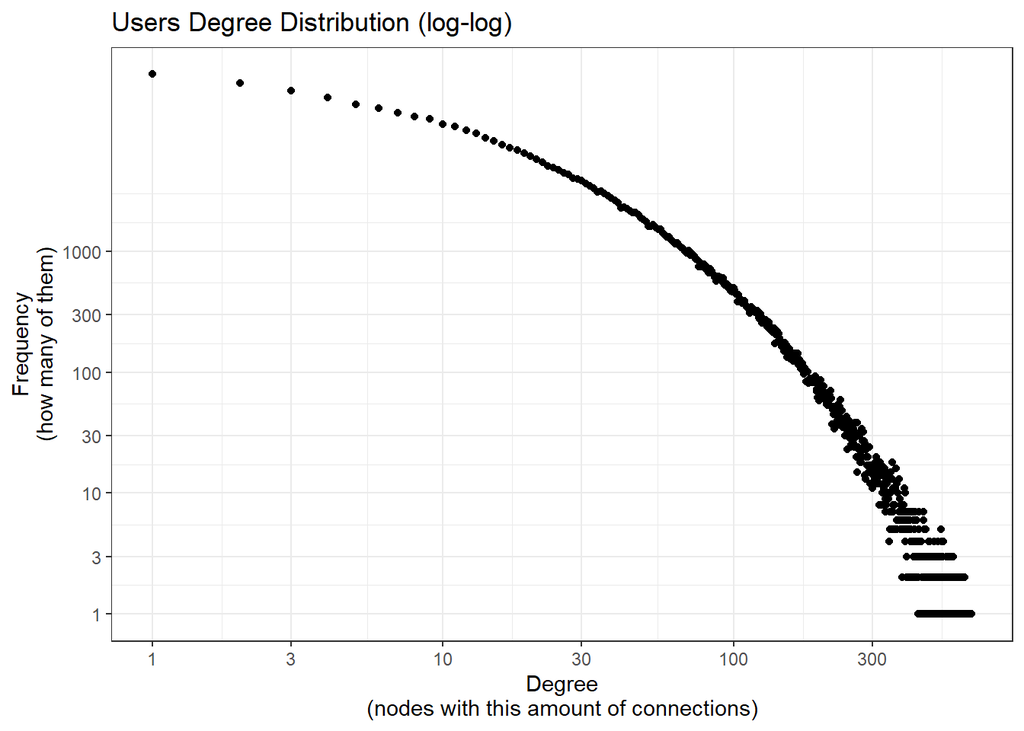

```r
plot_deg_distr(g, T) #deg_distr users
```

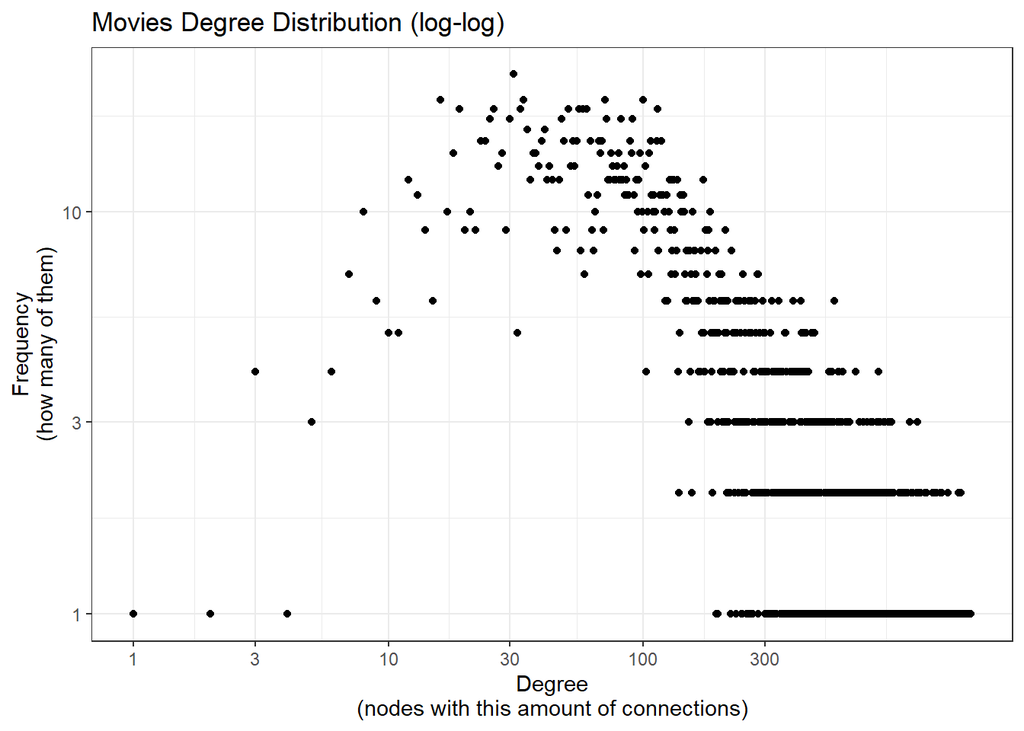

```r
plot_deg_distr(g, F) #deg_distr movies
```

#Let’s visualize g

```r
reduced_graph <- g

y <- length(get_users(reduced_graph))
new_users <- sample(get_users(g), y^sqrt(4.1/10))

x <- length(get_movies(reduced_graph))
new_movies <- sample(get_movies(g), x^(4.1/10))

reduced_graph <- reduced_graph <- induced_subgraph(reduced_graph, c(new_users, new_movies))

reduced_graph <- delete.vertices(reduced_graph, V(reduced_graph)[degree(reduced_graph)==0])
```

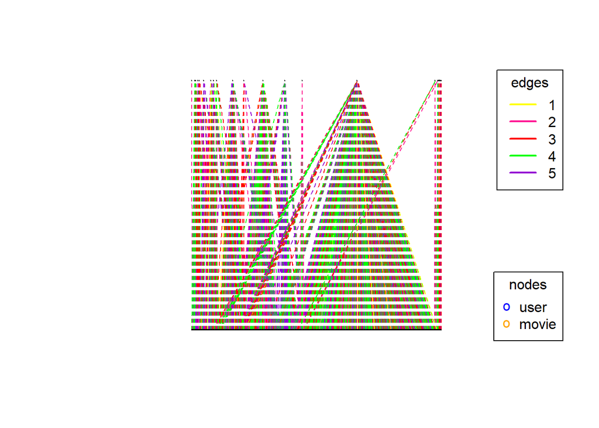

```r
plot(reduced_graph,
       vertex.label=NA,
       edge.size = 0.01,
       edge.lty = 2,
       vertex.size = 0.8,
       layout=layout_as_bipartite)
legend(x = "topright",                                              # Position
       legend = c(1, 2, 3, 4, 5),                                   # Legend texts
       col = c("yellow", "deeppink", "red", "green", "darkviolet"), # Line colors
       lwd = 2,                                                     # Line width
       title = "edges"
       )
legend(x = "bottomright",
       legend = c('user', 'movie'),
       col = c("blue", "orange"),
       pch = 'o',
       title = "nodes"
       )
```

#Here we divide the graph in 5 subragphs based on the weight

```r
weights <- E(reduced_graph)$weight
subg <- list()
for (r in seq(5)) {
  subg[[r]] <- delete.edges(reduced_graph, E(reduced_graph)[weights!=r])
  subg[[r]] <- delete.vertices(subg[[r]],
                                    V(subg[[r]])[degree(subg[[r]])==0])
}
```

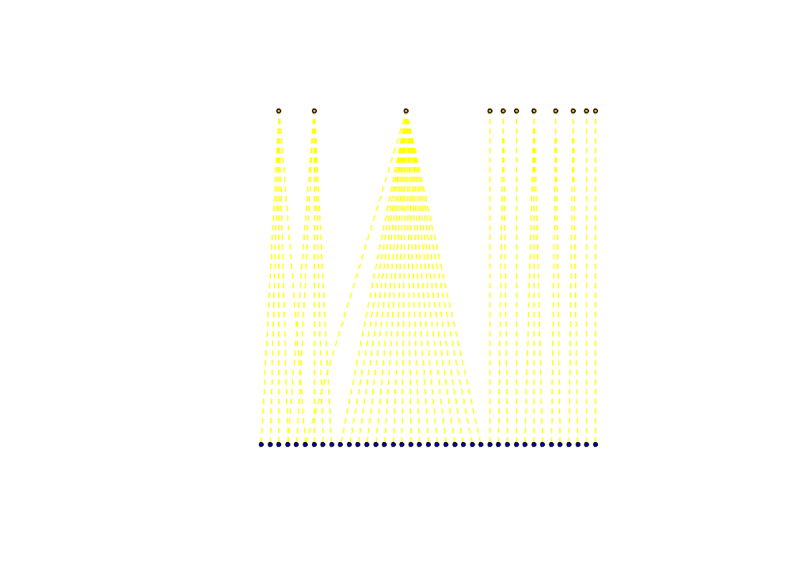

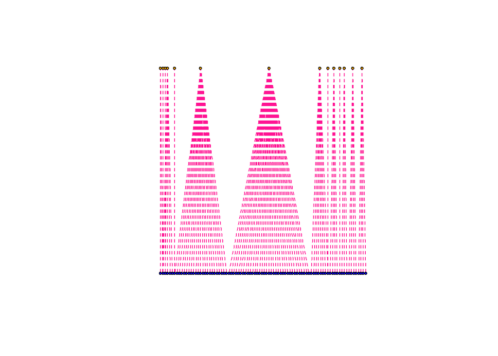

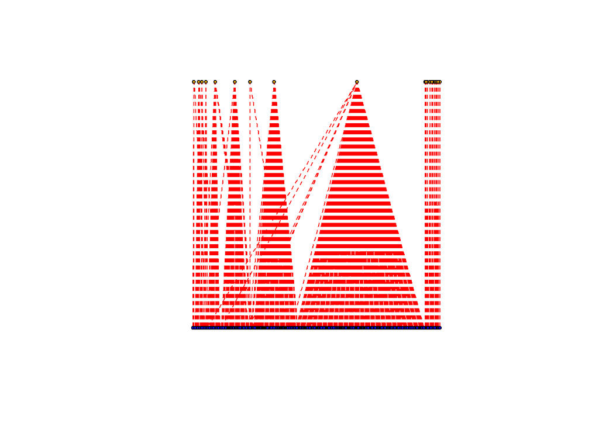

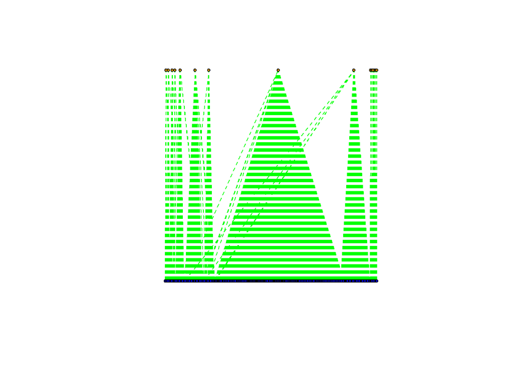

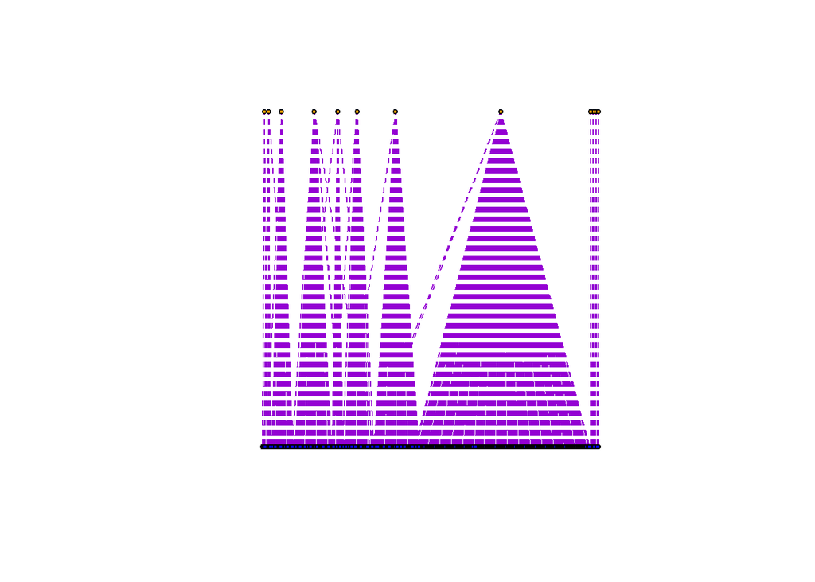

```r
for (r in seq(5)) {
  print(plot(subg[[r]],
       vertex.label=NA,
       edge.size = 0.1,
       edge.lty = 2,
       vertex.size = 3,
       weights = F,
       layout=layout_as_bipartite))
}
```

#BIPARTITE PROJECTION ON USERS

```r
y <- length(get_users(g))
rug <- induced_subgraph(g, c(sample(new_users, y^(3.33/10)), get_movies(g)))
rug <- delete.vertices(rug, V(rug)[degree(rug)==0])
```

#Bipartite projection on user for each subgraph

```r
weights <- E(rug)$weight
pu <- list() ##proj users
for (r in seq(5)) {
  pu[[r]] <- delete.edges(rug, E(rug)[weights!=r])
  pu[[r]] <- delete.vertices(pu[[r]], V(pu[[r]])[degree(pu[[r]])==0])
  a = as_incidence_matrix(pu[[r]])
  im_g_proj_user <- t(a)%*%a #proj users
  pu[[r]] <- graph_from_adjacency_matrix(im_g_proj_user, mode="undirected", weighted = T)
  pu[[r]] <- simplify(pu[[r]])
  pu[[r]] <- delete.vertices(pu[[r]], V(pu[[r]])[degree(pu[[r]])==0])
}
```

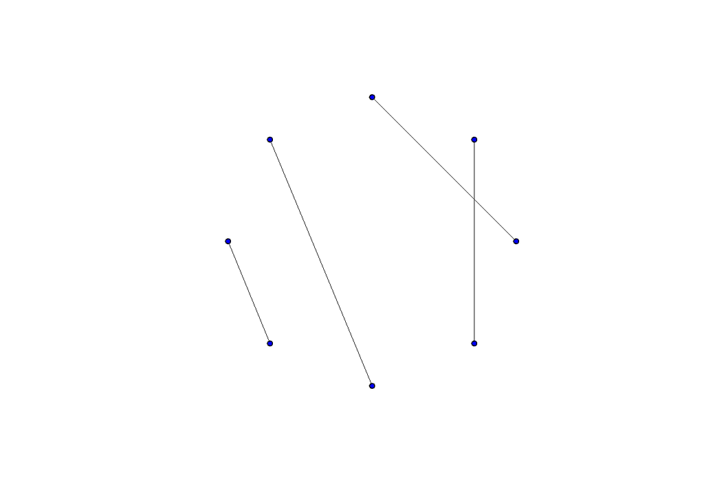

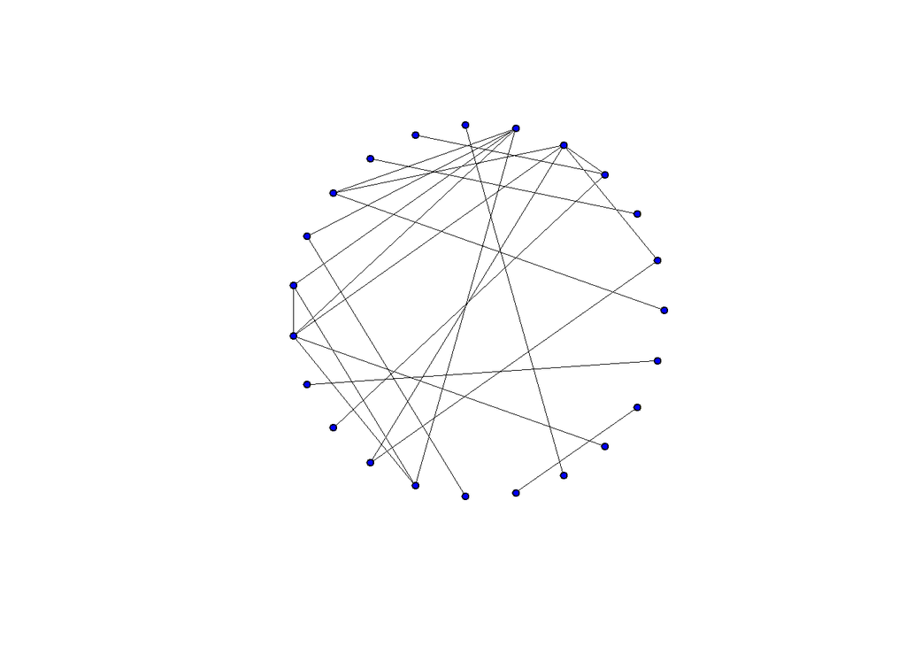

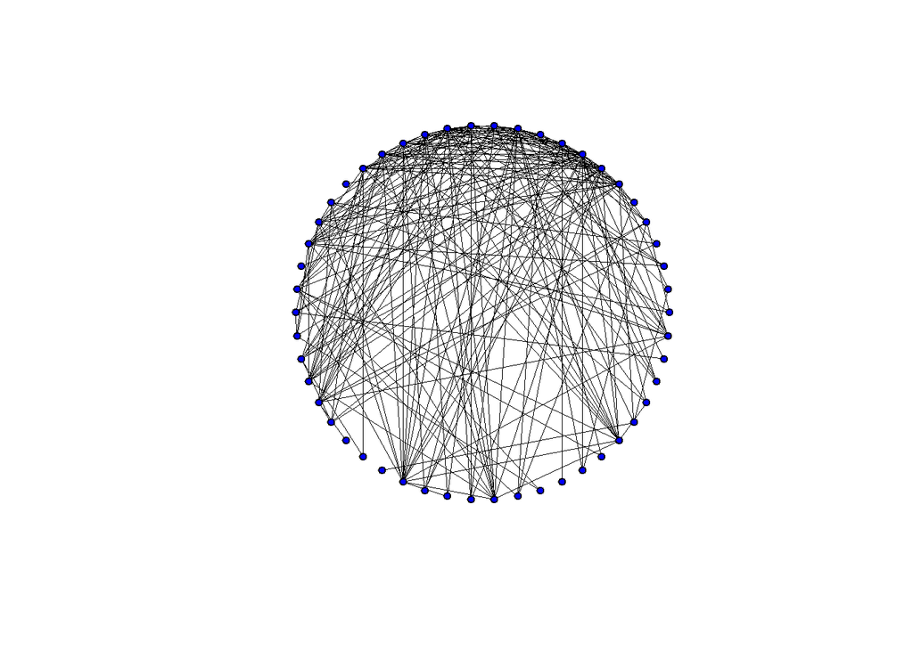

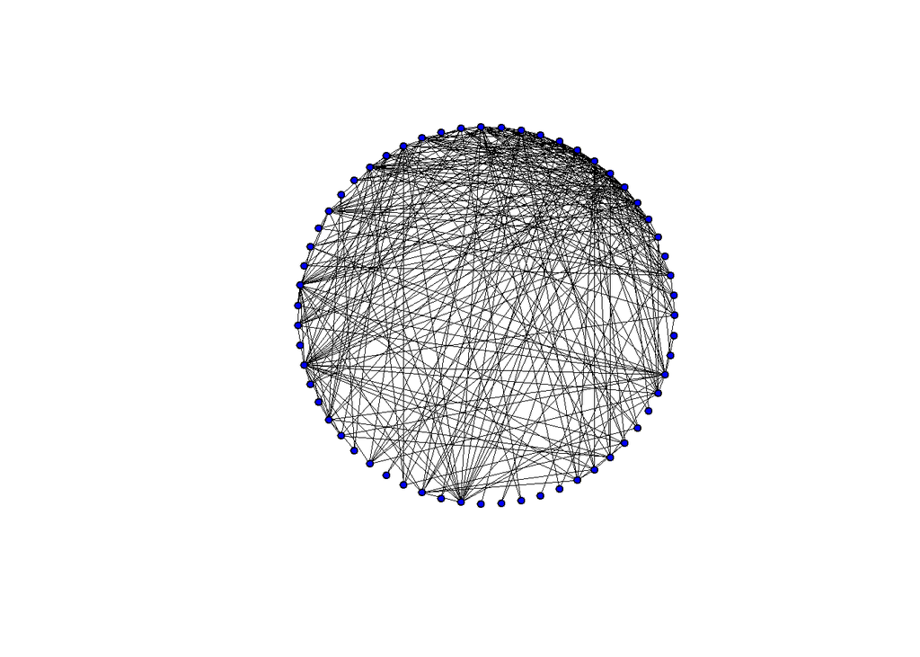

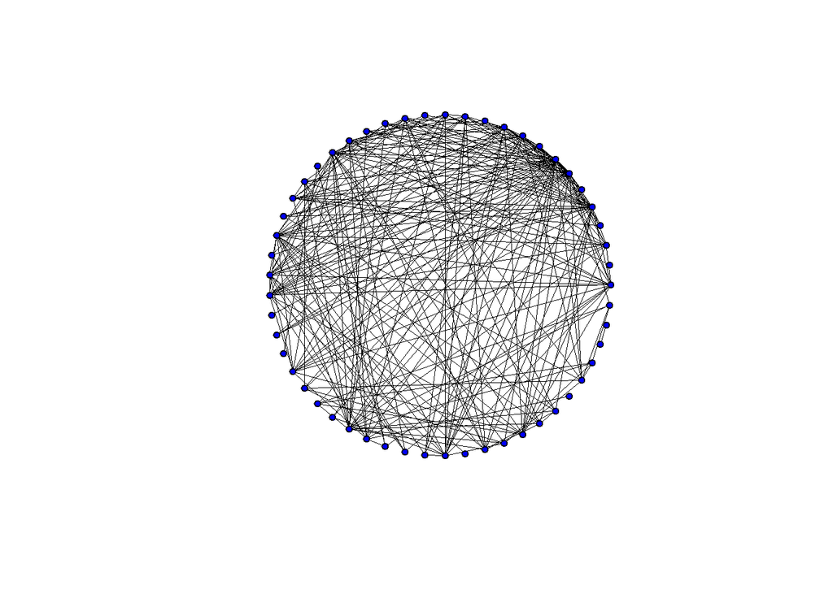

```r
for (r in seq(5)) {
  print(plot(pu[[r]],
       vertex.label=NA,
       edge.lty = 1,
       vertex.size = 4,
       vertex.color = "blue",
       edge.size = 0.1,
       edge.width = E(pu[[r]])$weight/10,
       edge.color = "black",
       layout = layout_in_circle
       ))
}
```

#Union on the projections

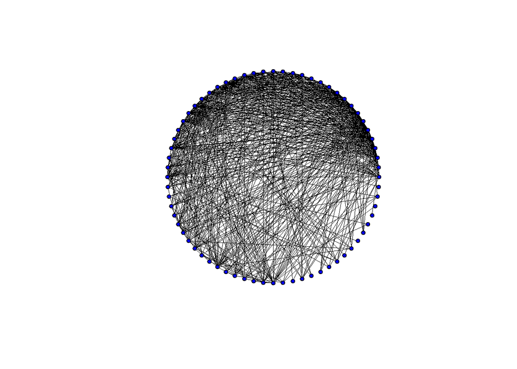

```r
dfu = do.call(
      rbind,
      lapply(pu, get.data.frame)
      )
dfu <- aggregate(weight~ ., dfu, sum)
upu <- graph_from_data_frame(dfu, directed = F)

plot(upu,
       vertex.label=NA,
       edge.size = 0.1,
       edge.lty = 1,
       vertex.size = 4,
       vertex.color = "blue",
       edge.width=E(upu)$weight/10,
       edge.color="black",
       layout = layout_in_circle)
```

#clustering

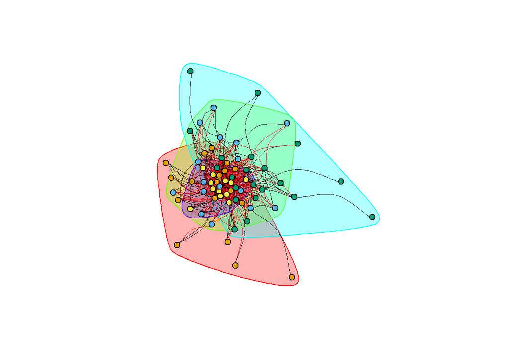

```r
cl_upu = cluster_fast_greedy(upu)

plot(cl_upu, upu,
     vertex.label = NA,
     vertex.size = 6,
     edge.size = 0.1,
     edge.lty = 1,
     edge.curved = TRUE,
     edge.width=E(upu)$weight/10,
     layout = layout_with_fr(upu)
     #layout=layout.circle(upu)
     )
```

#BIPARTITE PROJECTION ON MOVIES

```r
y <- length(get_movies(g))
rmg <- induced_subgraph(g, c(new_movies, get_users(g)))
rmg <- delete.vertices(rmg, V(rmg)[degree(rmg)==0])
```

#Bipartite projection on movies for each subgraph

```r
weights <- E(rmg)$weight
pm <- list() #proj movies
for (r in seq(5)) {
  pm[[r]] <- delete.edges(rmg, E(rmg)[weights!=r])
  pm[[r]] <- delete.vertices(pm[[r]], V(pm[[r]])[degree(pm[[r]])==0])
  a = as_incidence_matrix(pm[[r]])
  im_g_proj_movie <- a%*%t(a) #proj movies
  #pm[[r]] <- bipartite_projection(pm[[r]], multiplicity = T)$proj1
  pm[[r]] <- graph_from_adjacency_matrix(im_g_proj_movie, mode="undirected", weighted = T)
  pm[[r]] <- simplify(pm[[r]])
  pm[[r]] <- delete.vertices(pm[[r]], V(pm[[r]])[degree(pm[[r]])==0])
}
```

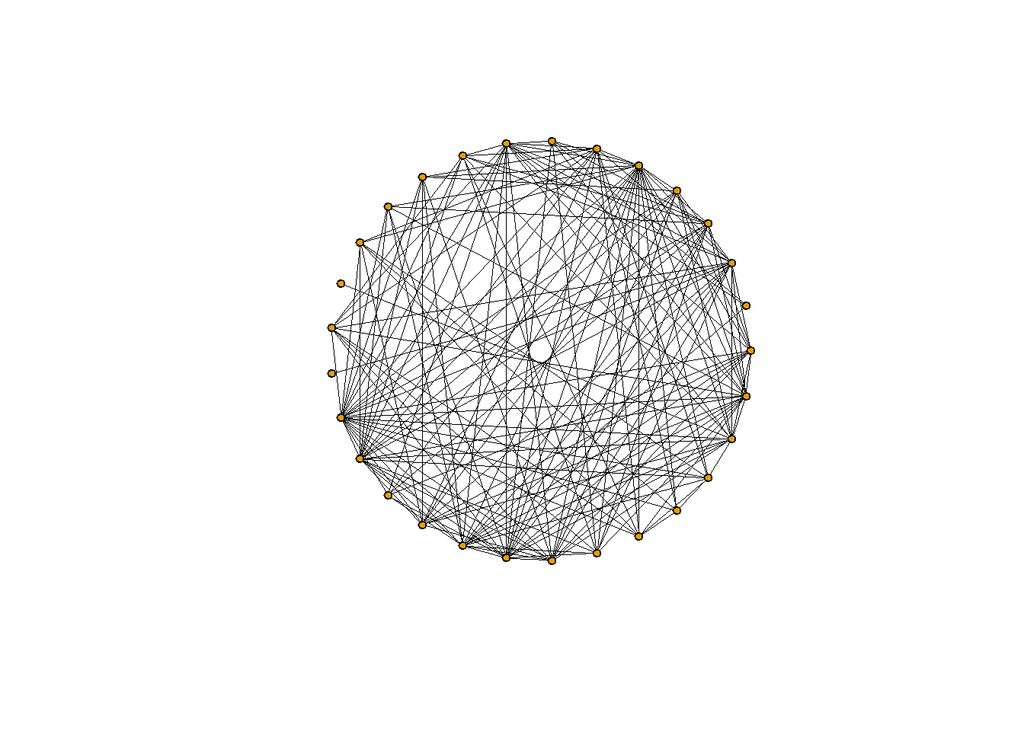

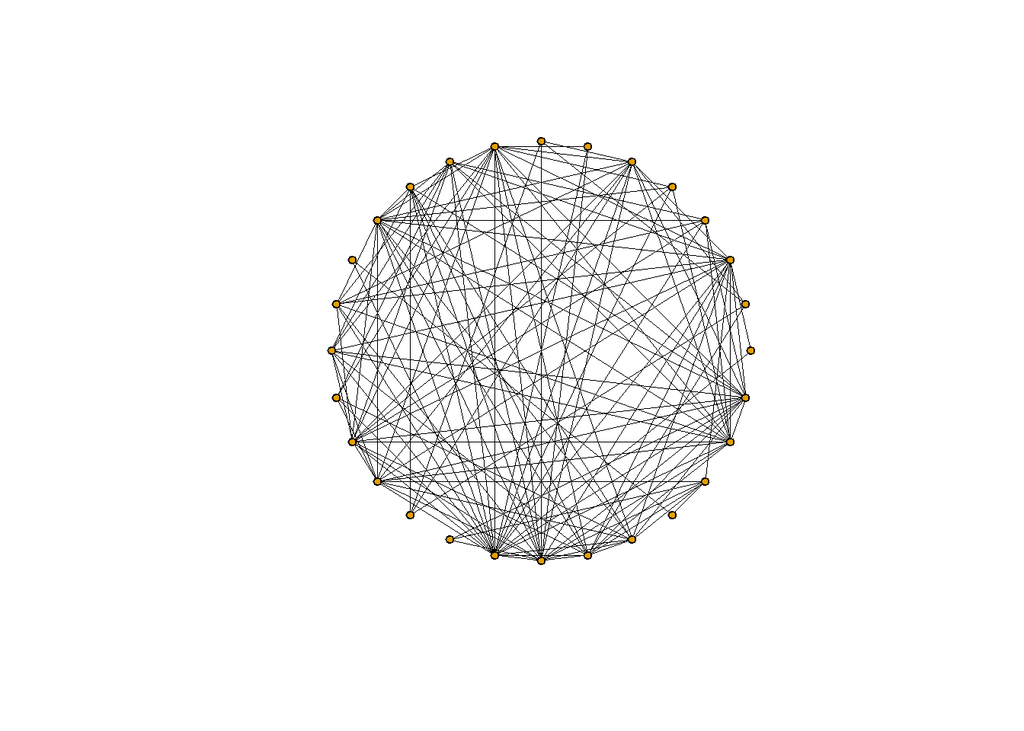

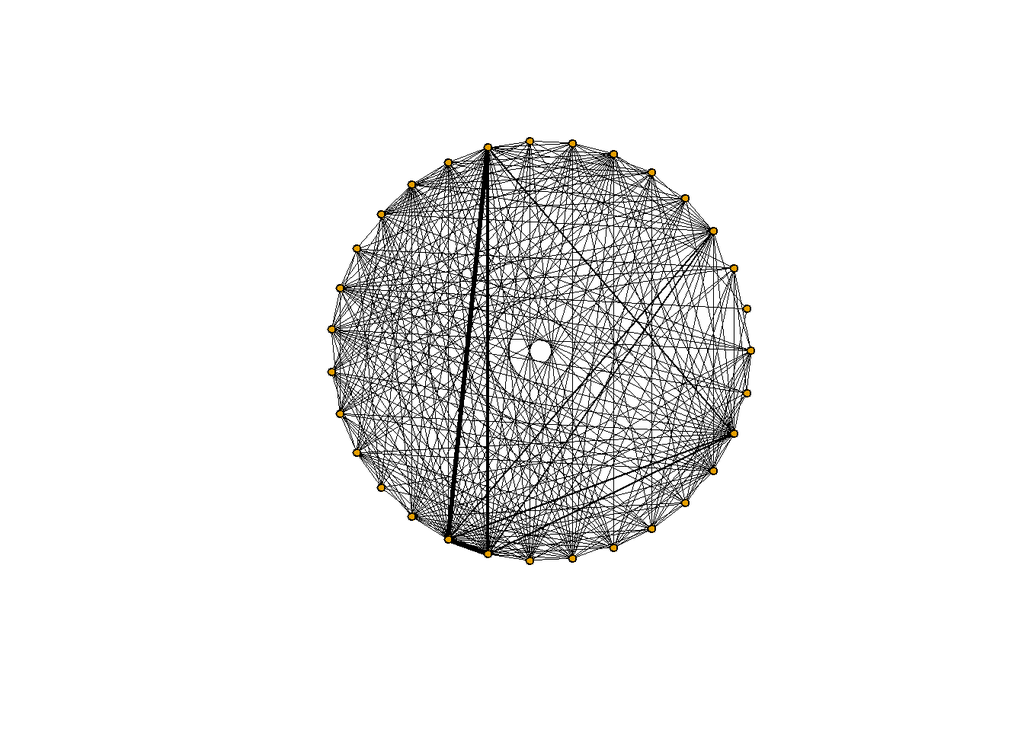

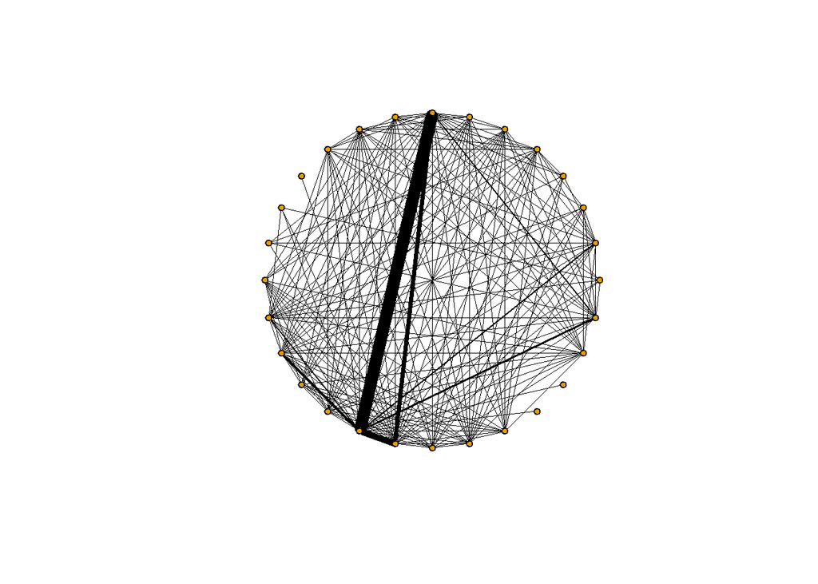

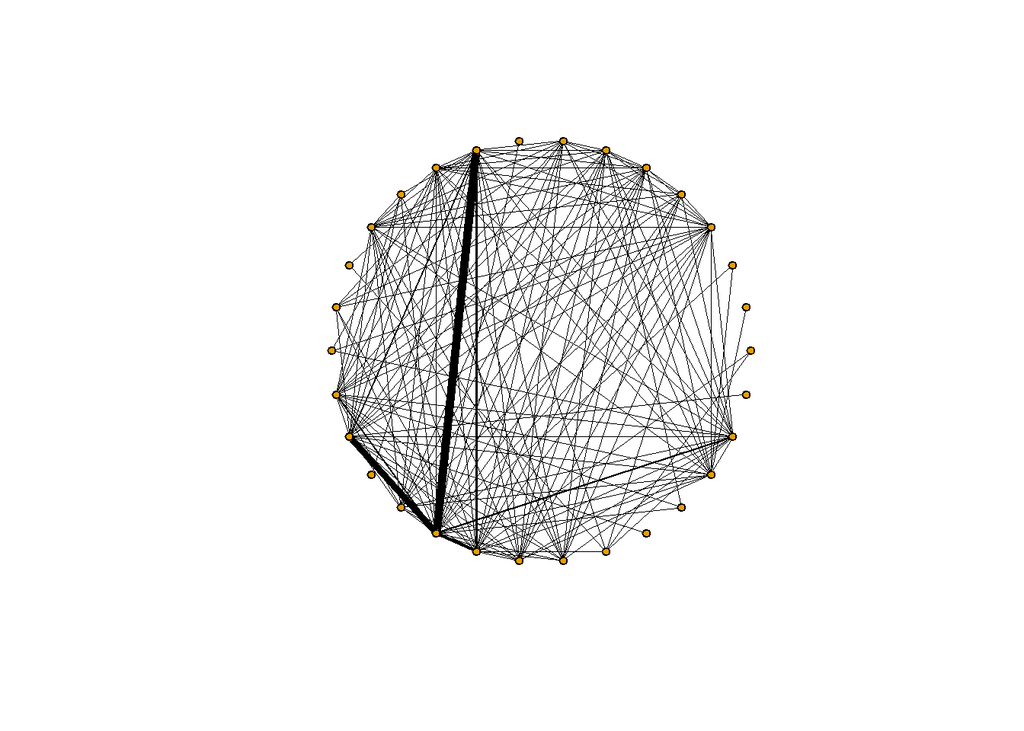

```r
for (r in seq(5)) {
  print(plot(pm[[r]],
       vertex.label=NA,
       edge.size = 0.1,
       edge.lty = 1,
       vertex.size = 4,
       edge.width=E(pm[[r]])$weight/100,
       edge.color = "black",
       layout = layout_in_circle))
}
```

#Union of the projections

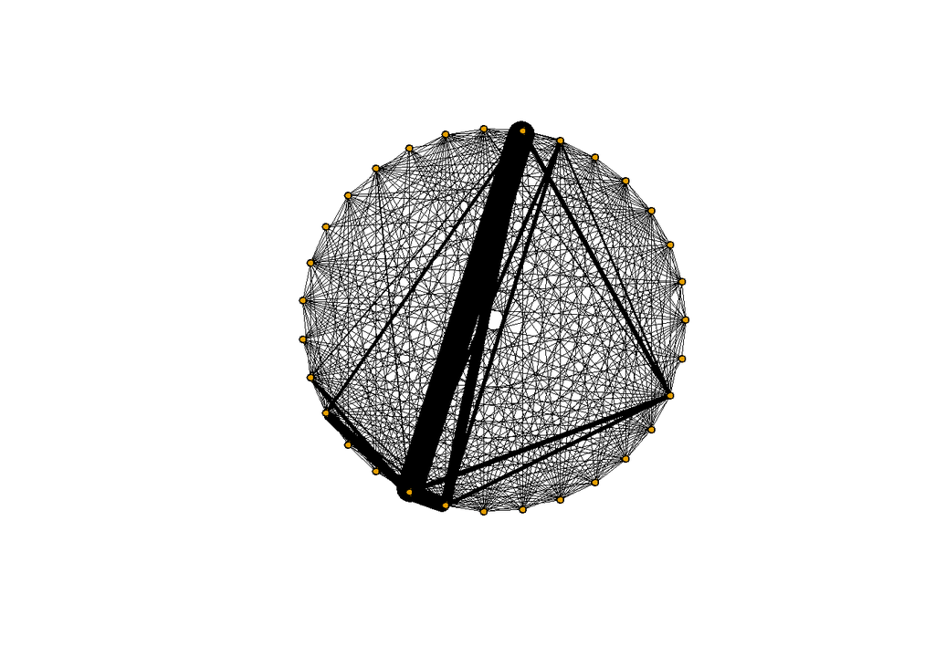

```r
dfm = do.call(
      rbind,
      lapply(pm, get.data.frame)
      )
dfm <- aggregate(weight~ ., dfm, sum)
upm <- graph_from_data_frame(dfm, directed = F)
plot(upm,
       vertex.label=NA,
       edge.size = 0.1,
       edge.lty = 1,
       vertex.size = 4,
       edge.width=E(upm)$weight/100,
       edge.color = "black",
       layout = layout_in_circle)
```

#Clustering

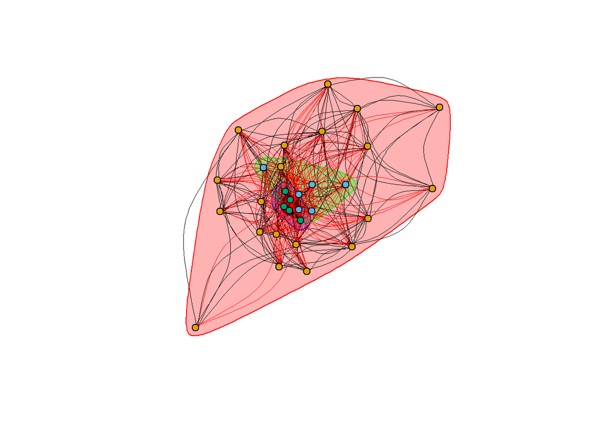

```r
cl_upm = cluster_fast_greedy(upm)

plot(cl_upm, upm,
     vertex.label = NA,
     vertex.size = 6,
     edge.size = 0.1,
     edge.lty = 1,
     edge.curved = TRUE,
     edge.width = E(upm)$weight/100,
     layout = layout_with_fr(upm)
     #layout=layout.circle(upm)
     )
```

#HOMOPHILY

```r
#we get a sample of movies with genre (obtained in the jupyter notebook file trhough API)
setwd(path)
sample_movie_titles <- read.csv("df/sample_movie_titles.csv")
head(sample_movie_titles)
```

```
##   movie_id year_of_release                      title     genre
## 1     2318            1996              Moving Target Adventure
## 2      384            1986                 Crossroads     Drama
## 3     4302            1982 An Officer and a Gentleman    Comedy
## 4     3647            1987      Death Before Dishonor     Drama
## 5     2309            1973                 Rhinoceros Animation
## 6     2371            1955           To Catch a Thief     Drama
```

```r
#Now we repeat the whole clustering process on the new sample of movies
new_movies <- get_movies(g)[as.numeric(get_movies(g)$name) %in% sample_movie_titles$movie_id]

y <- length(get_movies(g))
rmg <- induced_subgraph(g, c(new_movies, get_users(g)))
rmg <- delete.vertices(rmg, V(rmg)[degree(rmg)==0])

weights <- E(rmg)$weight
pm <- list() #proj movies
for (r in seq(5)) {
  pm[[r]] <- delete.edges(rmg, E(rmg)[weights!=r])
  pm[[r]] <- delete.vertices(pm[[r]], V(pm[[r]])[degree(pm[[r]])==0])
  a = as_incidence_matrix(pm[[r]])
  im_g_proj_movie <- a%*%t(a) #proj movies
  #pm[[r]] <- bipartite_projection(pm[[r]], multiplicity = T)$proj1
  pm[[r]] <- graph_from_adjacency_matrix(im_g_proj_movie, mode="undirected", weighted = T)
  pm[[r]] <- simplify(pm[[r]])
  pm[[r]] <- delete.vertices(pm[[r]], V(pm[[r]])[degree(pm[[r]])==0])
}

dfm = do.call(
      rbind,
      lapply(pm, get.data.frame)
      )
dfm <- aggregate(weight~ ., dfm, sum)
upm <- graph_from_data_frame(dfm, directed = F)

cl_upm = cluster_fast_greedy(upm)
```

```r
movies <- merge(sample_movie_titles,
                data.frame(movie_id = cl_upm$names,
                           clustering_membership = cl_upm$membership),
                by="movie_id")
movies <- movies[order(movies$clustering_membership), ]
rownames(movies) <- 1:nrow(movies)
movies
```

```
##    movie_id year_of_release                          title       genre
## 1        47            1952      The Bad and the Beautiful       Drama
## 2       104            1965                 The Great Race      Comedy
## 3       200            1964   The Fall of the Roman Empire       Drama
## 4       422            1964     The Unsinkable Molly Brown   Biography
## 5       570            2000                      The Visit       Drama
## 6      1067            1956   Earth vs. The Flying Saucers      Horror
## 7      1130            1991                      Impromptu      Comedy
## 8      1153            1943                    On Approval      Comedy
## 9      1332            1954                Sherlock Holmes      Horror
## 10     1338            1964                      The Patsy      Comedy
## 11     1419            1975                  Madame Bovary       Drama
## 12     1740            2001                    Say Nothing       Drama
## 13     1772            1964        Flipper's New Adventure      Family
## 14     1916            1985     Go Tell It on the Mountain       Music
```

[output cut: 67 more lines]

#Homophily among movies based on the year of release

```r
#first we compare the expected absolute value of the difference of years among two movies linked by an edge if the graph was random: E(abs(u1$year - u2$year) | G.israndom), with the actual average in this graph: mean(abs(u1$year - u2$year))

n_of_nodes <- length(V(upm))

exp_diff <- 0
for (y in movies$year_of_release) {
  for (k in movies$year_of_release) {
    exp_diff <- exp_diff + abs(y-k)
  }
}
exp_diff <- exp_diff/(n_of_nodes)/(n_of_nodes - 1)
exp_diff #E(abs(u1$year - u2$year) | G.israndom)
```

```
## [1] 20.66026
```